# CIA2

#### Objective 3

##### To visually identify the choice made by the customer based on whether they commute less than or more than 5 miles a day.

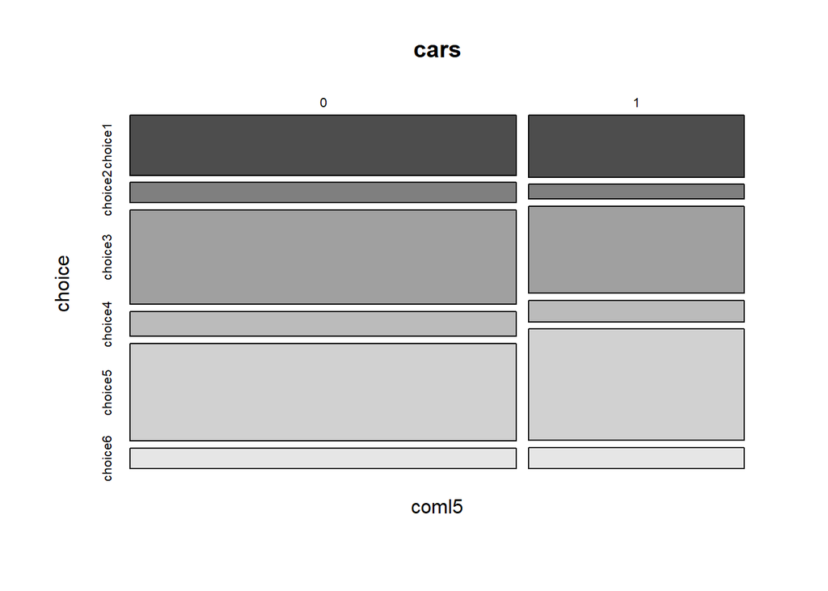

```r
mosaicplot(~ coml5+  choice, data = cars, color = T)
```

#### Source

##### McFadden, Daniel and Kenneth Train (2000) “Mixed MNL models for discrete response”, Journal of Applied Econometrics, 15(5), 447-470.

#### References

##### Journal of Applied Econometrics data archive : http://qed.econ.queensu.ca/jae/.

#### See Also

##### Index.Source, Index.Economics, Index.Econometrics, Index.Observations